# Usenet Analysis

Richard G. Gardiner

12/26/2018

This example comes from the final chapter of the Text Mining with R book. Here we will use the common Usenet bulletin board dataset to run a “start to finish” analysis. This dataset has 20,000 messages sent ot 20 Usenet boards in 1993. The data is available at http://qwone.com/~jason/20Newsgroups/ (use the `20news-bydate.tar.gz`)

## loading and pre-processing

We will start by reading all messages from the `20news-bydate.tar.gz` folder which are organized into subfolders with one file for each message. We can do this using a combination of read_lines, map(), and unnest().

```r
library(dplyr)
```

```r
library(tidyr)
library(purrr)
library(readr)

training_folder <- "20news-bydate/20news-bydate-train/"

# define a function to read all files from a folder into a data frame
read_folder <- function(infolder) {
  data_frame(file = dir(infolder, full.names = TRUE)) %>%
    mutate(text = map(file, read_lines)) %>%
    transmute(id = basename(file), text) %>%
    unnest(text)
}

# use unnest() and map() to apply read_folder to each subfolder
raw_text <- data_frame(folder = dir(training_folder, full.names = TRUE)) %>%
  unnest(map(folder, read_folder)) %>%
  transmute(newsgroup = basename(folder), id, text)

raw_text
```

```
## # A tibble: 511,655 x 3
##    newsgroup   id    text
##    <chr>       <chr> <chr>
##  1 alt.atheism 49960 From: mathew <mathew@mantis.co.uk>
##  2 alt.atheism 49960 Subject: Alt.Atheism FAQ: Atheist Resources
##  3 alt.atheism 49960 Summary: Books, addresses, music -- anything related …
##  4 alt.atheism 49960 Keywords: FAQ, atheism, books, music, fiction, addres…
##  5 alt.atheism 49960 Expires: Thu, 29 Apr 1993 11:57:19 GMT
##  6 alt.atheism 49960 Distribution: world
##  7 alt.atheism 49960 Organization: Mantis Consultants, Cambridge. UK.
##  8 alt.atheism 49960 Supersedes: <19930301143317@mantis.co.uk>
##  9 alt.atheism 49960 Lines: 290
## 10 alt.atheism 49960 ""
## # ... with 511,645 more rows
```

Note that hte `newsgroup` column, which describes which of hte 20 newsgroups each message comes from, and `id` column which identifies a unique message within that newsgroup. What newsgroups are incldued, and how many messages were posted in each?

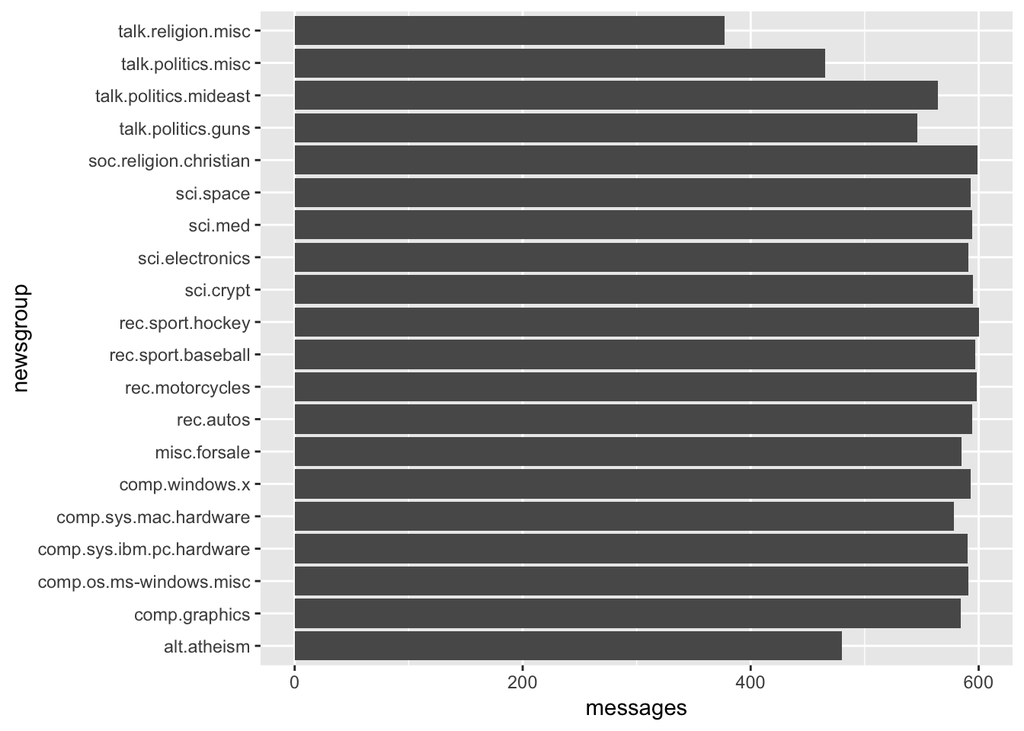

```r
library(ggplot2)

raw_text %>%
  group_by(newsgroup) %>%
  summarise(messages = n_distinct(id)) %>%
  ggplot(aes(x = newsgroup, y = messages)) +
  geom_col() +
  coord_flip()
```

We can see that the names are hierarchically grouped, starting with main topic such as `“talk”, “sci”, or “rec”.

### Pre-Processing Text

Unlike the other texts, this dataset has some strucutre and extra text that we don’t want to analyze and thus needs to be removed. For example, each message has a header, contaiing fields such as “from:” or “in_reply_to:” that describe the message. Some also have automated email signatures, which occur after a line like `--`. We can generally do this pre-processing suing the dplyr package, using a combination of `cumsum()` and `str_detect()` from stringr.

```r
library(stringr)

# must occur after the first occurence of an empty line,
# and before the first occurence of a line starting with --
cleaned_text <- raw_text %>%
  group_by(newsgroup, id) %>%
  filter(cumsum(text == "") > 0,
         cumsum(str_detect(text, "^--")) == 0) %>%
  ungroup()

cleaned_text
```

```
## # A tibble: 364,390 x 3
##    newsgroup   id    text
##    <chr>       <chr> <chr>
##  1 alt.atheism 49960 ""
##  2 alt.atheism 49960 Archive-name: atheism/resources
##  3 alt.atheism 49960 Alt-atheism-archive-name: resources
##  4 alt.atheism 49960 Last-modified: 11 December 1992
##  5 alt.atheism 49960 Version: 1.0
##  6 alt.atheism 49960 ""
##  7 alt.atheism 49960 "                              Atheist Resources"
##  8 alt.atheism 49960 ""
##  9 alt.atheism 49960 "                      Addresses of Atheist Organizat…
## 10 alt.atheism 49960 ""
## # ... with 364,380 more rows
```

Many lines also have nested text representing quotes from other users, typically starting with a line like “so-and-so writes…” These can be removed with a few regular expression. We alsochose to manually remove two messages, 9704 and 9985 which contain a large amount of non-text content.

```r
cleaned_text <- cleaned_text %>%
  filter(str_detect(text, "^[^.]+[A-Za-z\\d]") | text == "",
         !str_detect(text, "writes(:|\\.\\.\\.)$"),
         !str_detect(text, "^In article <"),
         !id %in% c(9704, 9985))
```

```r
library(tidytext)

unnest_words <- cleaned_text %>%
  unnest_tokens(word, text) %>%
  filter(str_detect(word, "[a-z']$"),
         word %in% stop_words$word)
```

Almost all datasets will require some cleaning and processing. This happens through a lot of trial and error. Though, as we can see, most of this can be done using the tidy tools like dplyr and tidyr.